# Empirical inference for agent-based models, where are we going next?

# Empirical induction in complex systems

## What is a model?

- A model is:
  - a collection of causal relationships
  - embedded in algorithms
  - modulated by parameters
  - **counterfactual**
- Data is:
  - **factual**
- Estimation/Calibration
  - Set **counterfactual** parameters through **factual** observations

## The problem of induction

- Set **counterfactual** parameters through **factual** observations
  - Learn about what could have happened given what happened
- Let’s do it! Can it be done?
  - Depends on the assumed model
  - Depends on the availability of data
  - Depends on the technique used
    - Sometimes it cannot be done
    - Most of the time, it can only be done in parts
  - **under-identification**

## Macroeconomics example

Canova, Fabio, and Luca Sala. “Back to square one: Identification issues in DSGE models.” Journal of Monetary Economics 56.4 (2009): 431-449.

- Weak identification pervasive in DSGE
- Validation techniques (comparing impulse responses out-of-sample) do not help
- $\to$ wrong with high degree of confidence

## What to do?

- Accept identification issues
  1. Use methods that are honest about unknown parameters
  2. Try to see if anything can be said with some/all unknown parameters
- Add assumptions to make it more identifiable
  - Manski’s *law of decreasing credibility*
  - “Stronger assumptions yield conclusions that are more powerful but less credible”

# Estimation methods

## Kinds of parameters

[figure not shown]

- Some can be set directly
- Others need some estimation
- Often we don’t know

## Example fishing boats

- Building an ABM of boats going fishing
- Key parameter: number of boats
- If we have data on number of boats: no estimation needed
  - what if boats are heterogeneous?
  - size, captain’s skill, quality of maintenance…
- Ignore heterogeneity $\to$ lack of realism?
- Accept heterogeneity $\to$
  1. more complexity
  2. more parameters
- Abstract away $\to$
  1. ignore boats, focus on “fishing power”

## Public health example

Murray, E. J., Robins, J. M., Seage, G. R., Freedberg, K. A., & Hernán, M. A. (2020). The Challenges of Parameterizing Direct Effects in Individual-Level Simulation Models.

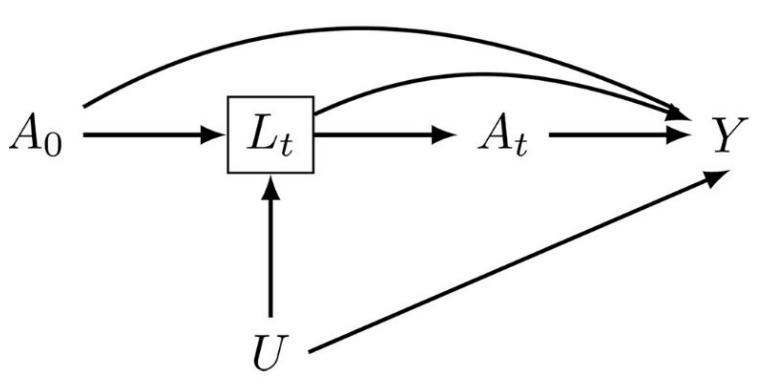

# Targets

## The main practical challenge

- In equation-based models
  $$f(\theta)$$
  - Make some assumptions about data $x$ such that we can write likelihood function
    $$L(\theta | x)$$

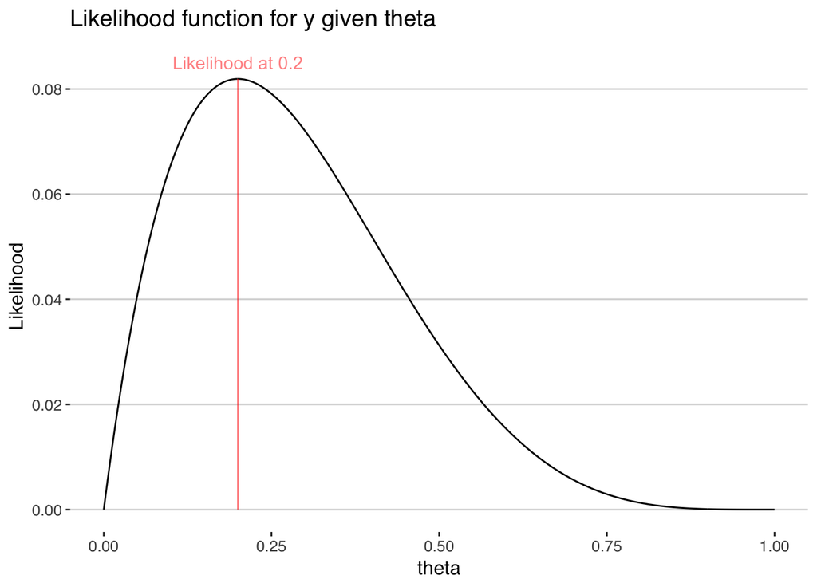

  - Find the parameters $\theta$ that maximize the likelihood

## In simulation methods

- Likelihood is unknown and intractable
- Need to focus on likelihood-free methods

## Simulation alternatives

- By target
  - Curve Matching
  - Likelihood substitutes
  - Summary statistics
- By method
  - Accept/Reject
  - Minimization
  - Meta-modelling
  - Regression-based

## What we want in a method

- Efficiency
- Theoretical guarantees
- Confidence intervals
- Can test its identification performance

## Naive method

- Match a simulated “curve” against a real one
  - “minimize mean square error”

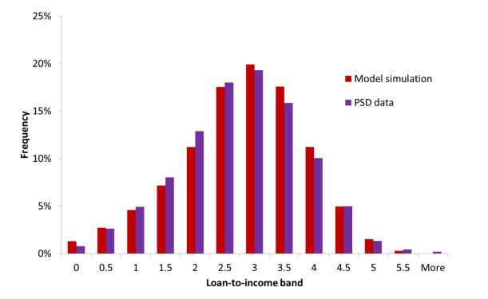

- Baptista, Rafa, et al. “Macroprudential policy in an agent-based model of the UK housing market.” (2016).

## Naive method

- Weaknesses:
  - No confidence intervals
  - Local minima and under-identification
  - Expensive to test
- Consequences
  - Sensitivity analysis needs to be wide
  - Validation needs to be thorough

## Likelihood alternatives

- ABMs likelihoods are unknown
- If your model is *very* fast:
  - MC likelihood
  - Pseudo-likelihood

## Example: animal tracking

Hooten, M., Wikle, C., & Schwob, M. (2020). Statistical Implementations of Agent‐Based Demographic Models. International Statistical Review, https://doi.org/10.1111/insr.12399

- Tracking a set of animals
  - Each step, they survive with probability $\theta$
  - Each step, if alive, their tracker reports their presence with probability $p$
- Given a set of track time series
  - What are $\theta$ and $p$

## Example: animal tracking (2)

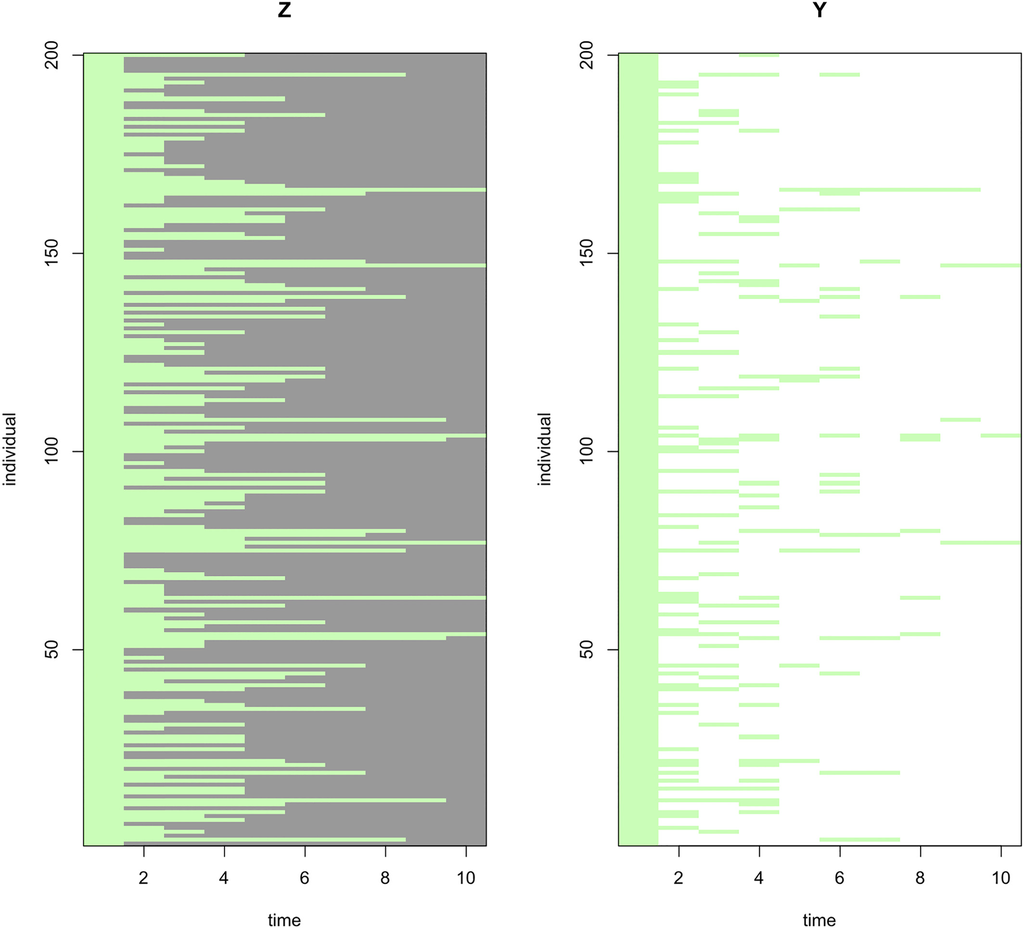

## Example: animal tracking (3)

- MC Likelihood:
  - Pick $\theta,p$
  - Run *many* simulations
  - Likelihood is how many individual time series match entirely
- Pseudo-likelihood:
  - Pick $\theta,p$
  - Run *many* simulations
  - Likelihood is how many observations at each time point for each individual match

## Likelihood alternatives - problems

- Computational expensive
- Only point estimates:
  - Need to validate
  - Need to do sensitivity analysis
- In large time series exact matches are very unlikely

## Summary statistics

- Summarise real world data into a set of statistics
- Summarise synthetic data into the same set
- Get them as close as possible:
  $$\min (\beta_{\text{real}} - \beta_{\text{abm}}(\theta))^T W (\beta_{\text{real}} - \beta_{\text{abm}}(\theta))$$
- Two conceptual schools of thought:
  - Indirect inference
  - Approximate Bayesian Computation
- Connection to “Pattern Oriented Modelling”

## Indirect Inference (example)

- Zhao, Linqiao. A model of limit-order book dynamics and a consistent estimation procedure. Diss. Carnegie Mellon University, 2010.

# Methods

## Accept/Reject

- Set a distance $\epsilon$ to the target
  1. Randomly sample parameters $\theta$
  2. Run the model with the random parameters
  3. Accept if you are less than $\epsilon$ away from your target
- Very inefficient!
- Generates confidence intervals
- Can be made “Bayesian” (ABC) by adding priors
- Easy to test

## Simple Rejection ABC, example:

van der Vaart, E., Beaumont, M. A., Johnston, A. S. A., & Sibly, R. M. (2015). Calibration and evaluation of individual-based models using Approximate Bayesian Computation. Ecological Modelling, 312, 182–190. https://doi.org/10.1016/j.ecolmodel.2015.05.020

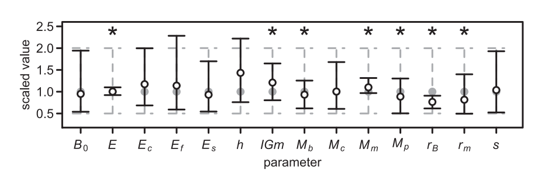

## Complicated rejection example:

Seri, R., Martinoli, M., Secchi, D., & Centorrino, S. (2021). Model calibration and validation via confidence sets. Econometrics and Statistics, 20, 62-86.

## Minimization

- Tune the parameters $\theta$ so that:
  - Maximize likelihood
  - Minimize Error
  - Minimize summary statistics distance
- Many options:
  - Genetic Algorithms
  - Hill-climbers
  - Particle swarms

## Minimization - example

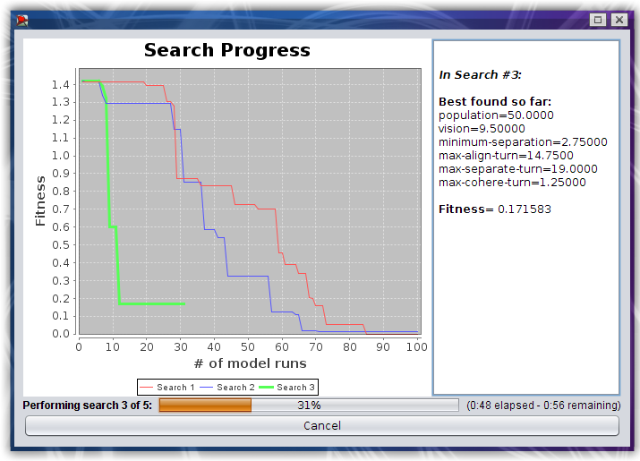

Robles, J. F., Bermejo, E., Chica, M., & Cordón, Ó. (2021). Multimodal Evolutionary Algorithms for Easing the Complexity of Agent-Based Model Calibration. Journal of Artificial Societies and Social Simulation, 24(3).

## Meta-modelling

- Tune the parameters $\theta$ so that:
  - Maximize likelihood
  - Minimize Error
  - Minimize summary statistics distance
- Do not do it directly
  - Instead train an intermediate Gaussian Process
  - Maximize that surface instead

## Meta-modelling - example

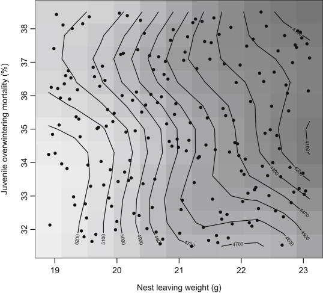

Parry, Hazel R., Christopher J. Topping, Marc C. Kennedy, Nigel D. Boatman, and Alistair W.A. Murray. ‘A Bayesian Sensitivity Analysis Applied to an Agent-Based Model of Bird Population Response to Landscape Change’. Environmental Modelling and Software 45 (July 2013): 104–15. https://doi.org/10.1016/j.envsoft.2012.08.006.

## Regression method

- Avoid minimizing/weighing altogether
- Run model many times (like rejection ABC)
- Create a table of parameters $\to$ summary statistics
- Use a regression to do the inverse connection, summary statistics $\to$ parameters
  - Gets you confidence intervals on all parameters
  - Easy to test identification
  - Not efficient
- Carrella, E., Bailey, R., & Madsen, J. (2020). Calibrating Agent-Based Models with Linear Regressions. Journal of Artificial Societies and Social Simulation, 23(1). https://doi.org/10.18564/jasss.4150

## New regression methods

- Neural networks very popular now
  - BayesFlow: `bayesflow`
  - SNPE-C: `sdi`

## Neural Network - examples

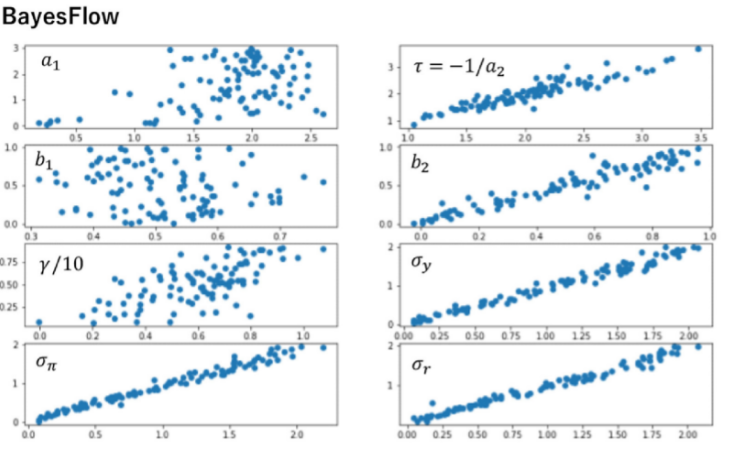

Shiono, T. (2021). Estimation of agent-based models using Bayesian deep learning approach of BayesFlow. Journal of Economic Dynamics and Control, 125, 104082.

## Analysis paralysis

- Too many methods! What shall I choose?
- Carrella, E. (2021). No Free Lunch when Estimating Simulation Parameters. Journal of Artificial Societies and Social Simulation, 24(2).
- No free lunch
  - Best “method” differs between models
  - Every method is the “best” in at least one case
  - Half the ABM tested were only partially identified

# Conclusion

## Priorities

1. Figure out what parameters been identified
   - confidence intervals
   - cross-validation
2. Carry over that uncertainty when doing policy analysis
   - Sensitivity analysis bounds
3. Validate